# AE 07: Joining

Suggested answers

**Important**

These are suggested answers. This document should be used as reference only, it’s not designed to be an exhaustive key.

## Goal

Let’s suppose we were interested in examining the total populations of continents. However, these are the two data sets we have available:

- world-pop-22.csv: contains data from The World Bank with countries’ populations
- continents.csv: contains data mapping countries to continents

To do analysis of population by continent, we need to join!

#### Load packages and read in data

```r
library(tidyverse)
population <- read_csv("data/world-pop-2022.csv")
continents <- read_csv("data/continents.csv")
```

#### Take a look at the data:

```r
population
```

```
# A tibble: 217 × 3
   country              year population
   <chr>               <dbl>      <dbl>
 1 Afghanistan          2022    41129.
 2 Albania              2022     2778.
 3 Algeria              2022    44903.
 4 American Samoa       2022       44.3
 5 Andorra              2022       79.8
 6 Angola               2022    35589.
 7 Antigua and Barbuda  2022       93.8
 8 Argentina            2022    46235.
 9 Armenia              2022     2780.
10 Aruba                2022      106.
# ℹ 207 more rows
```

```r
continents
```

```
# A tibble: 285 × 4
   entity                code      year continent
   <chr>                 <chr>    <dbl> <chr>
 1 Abkhazia              OWID_ABK  2015 Asia
 2 Afghanistan           AFG       2015 Asia
 3 Akrotiri and Dhekelia OWID_AKD  2015 Asia
 4 Aland Islands         ALA       2015 Europe
 5 Albania               ALB       2015 Europe
 6 Algeria               DZA       2015 Africa
 7 American Samoa        ASM       2015 Oceania
 8 Andorra               AND       2015 Europe
 9 Angola                AGO       2015 Africa
10 Anguilla              AIA       2015 North America
# ℹ 275 more rows
```

### Question 1: Join Concept

We want to know what continent *all* of the variables in the `population` data frame are in.

- What type of join should we use?

Left join with `population` as the “left” or “main” df because we want to keep all info in this df & supplement with info from `continents`

- Which variable in each data frame should we use?

Country & Entity

### Question 2: Implement the Join

Join the two data frames and name assign the joined data frame to a new data frame `population_continents` .

```r
population_continents <- population |>
  left_join(
    continents,
    by = join_by(country == entity)
  )

population_continents
```

```
# A tibble: 217 × 6
   country             year.x population code  year.y continent
   <chr>                <dbl>      <dbl> <chr>  <dbl> <chr>
 1 Afghanistan           2022    41129.  AFG     2015 Asia
 2 Albania               2022     2778.  ALB     2015 Europe
 3 Algeria               2022    44903.  DZA     2015 Africa
 4 American Samoa        2022       44.3 ASM     2015 Oceania
 5 Andorra               2022       79.8 AND     2015 Europe
 6 Angola                2022    35589.  AGO     2015 Africa
 7 Antigua and Barbuda   2022       93.8 ATG     2015 North America
 8 Argentina             2022    46235.  ARG     2015 South America
 9 Armenia               2022     2780.  ARM     2015 Asia
10 Aruba                 2022      106.  ABW     2015 North America
# ℹ 207 more rows
```

How does that look? Take a look at your new data frame!

### Question 3: What went wrong?

It might not be obvious, but something is a little weird about this. Go ahead and `filter` the resulting data frame to see if any of the continent values are `NA`.

```r
population_continents |>
  filter(is.na(continent))
```

```
# A tibble: 6 × 6
  country                   year.x population code  year.y continent
  <chr>                      <dbl>      <dbl> <chr>  <dbl> <chr>
1 Congo, Dem. Rep.            2022     99010. <NA>      NA <NA>
2 Congo, Rep.                 2022      5970. <NA>      NA <NA>
3 Hong Kong SAR, China        2022      7346. <NA>      NA <NA>
4 Korea, Dem. People's Rep.   2022     26069. <NA>      NA <NA>
5 Korea, Rep.                 2022     51628. <NA>      NA <NA>
6 Kyrgyz Republic             2022      6975. <NA>      NA <NA>
```

There are! This means that there were no rows in the `continents` data frame with those countries. That seems a little weird. Take a scroll through the continents data frame.

*Do you see what the cause of this is??*

### Question 4: Let’s fix this!

So, countries have to be spelled the exact same way in each data set. The code below renames the missing countries in the `population` data set to match the spelling in `contintents`; we will discuss `case_when()` and other similar functions in more detail next week! Run this code first, and then re-run the join in the subsequent code chunk: we are no longer missing these values!

```r
population_new_spellings <- population |>
  mutate(country = case_when(
    country == "Congo, Dem. Rep." ~ "Democratic Republic of Congo",
    country == "Congo, Rep." ~ "Congo",
    country == "Hong Kong SAR, China" ~ "Hong Kong",
    country == "Korea, Dem. People's Rep." ~ "North Korea",
    country == "Korea, Rep." ~ "South Korea",
    country == "Kyrgyz Republic" ~ "Kyrgyzstan",
    .default = country
    )
  )
```

```r
population_continent_new = population_new_spellings |>
  left_join(continents, by = join_by(country == entity))
```

Are there any NAs left? Run the code to see!

```r
population_continent_new |>
  filter(is.na(continent))
```

```
# A tibble: 0 × 6
# ℹ 6 variables: country <chr>, year.x <dbl>, population <dbl>, code <chr>,
#   year.y <dbl>, continent <chr>
```

## The Bigger Picture

How does what we just did fit into the bigger picture of the class?

- You are almost never going to be joining data sets just for fun! Joining data sets is a way to enable investigating more interesting patterns in data.
- Now, you could use your joined df to create plots or compute summary statistics to investigate the relationship between continent and total population.
- Keep joining in mind when you are looking for datasets in your project teams… if you find two datasets that share some common information, feel free to join them into a larger dataset for exploration!

*For extra practice,* try making a bar plot of total population in each country.

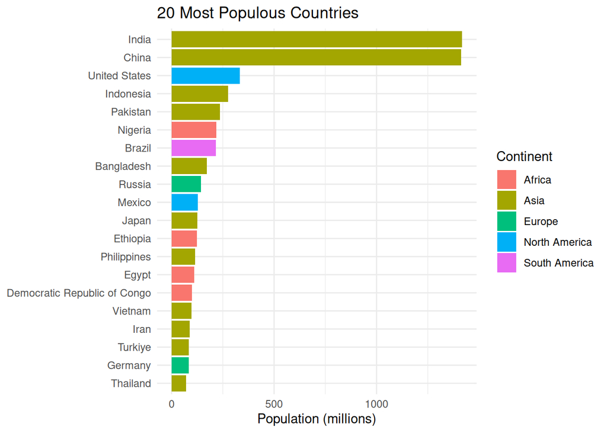

```r
population_continent_new <- population_continent_new |>
  mutate(population = population / 1000)

## subset the data and plot only the top 20 most populous countries

top_20 <- population_continent_new |>
  slice_max(population, n = 20)

top_20 |>
  ggplot(aes(x = population, y = fct_reorder(country, population),
             fill = continent)) +
  geom_col() +
  labs(title = "20 Most Populous Countries",
       x = "Population (millions)",
       y = NULL,
       fill = "Continent") +
  theme_minimal()
```

*To see something new,* try making a ‘lollipop chart’ of population by country (hint: this will require using `geom_point()` and `geom_segment()`.

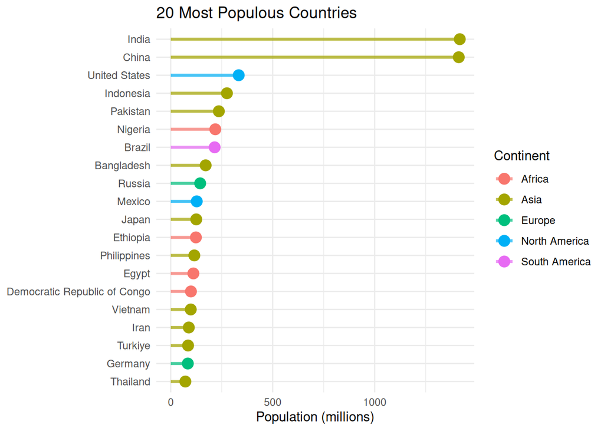

```r
top_20 |>
  ggplot(aes(x = population, y = fct_reorder(country, population),
             color = continent)) +
  # line segment
  geom_segment(aes(x = 0, xend = population,
                   y = country, yend = country),
               lwd = 1.2, alpha = 0.7) +
  # point at the end
  geom_point(size = 4) +
  labs(
    title = "20 Most Populous Countries",
    x = "Population (millions)",
    y = NULL,
    color = "Continent"
  ) +
  theme_minimal()
```